# Расчётная работа по предмету "ТВиМС"

Данная работа содержит результаты анализа данных производства и продажи мёда в США (1998-2012 г.)

Результаты работы представлены в виде таблиц, графиков и строчек кода с комментариями.

Выполнил: студент группы 651006, Борисевич Даниил

## Шаг 1. Экспорт данных в систему обработки

Для анализа и визуализации данных используется язык программирования Python, а также библиотеки Numpy, Pandas и Matplotlib.

Первым делом подключим необходимые библиотеки и установим настройки локализации:

```python
%matplotlib inline
import matplotlib as mpl
import matplotlib.pyplot as plt

default_dpi = mpl.rcParamsDefault['figure.dpi']
mpl.rcParams['figure.dpi'] = default_dpi * 0.9

import pandas as pd
import numpy as np
import sys
import math
from collections import Counter
stdout = sys.stdout
reload(sys)
sys.setdefaultencoding('utf-8')
sys.stdout = stdout
```

Исходные данные хранятся в CSV-таблице размером 626x8.

```python
data = pd.read_csv("honeyproduction.csv", header=0, sep=",")
data
```

|  | state | numcol | yieldpercol | totalprod | stocks | priceperlb | prodvalue | year |
| --- | --- | --- | --- | --- | --- | --- | --- | --- |
| 0 | AL | 16000.0 | 71 | 1136000.0 | 159000.0 | 0.72 | 818000.0 | 1998 |
| 1 | AZ | 55000.0 | 60 | 3300000.0 | 1485000.0 | 0.64 | 2112000.0 | 1998 |
| 2 | AR | 53000.0 | 65 | 3445000.0 | 1688000.0 | 0.59 | 2033000.0 | 1998 |
| 3 | CA | 450000.0 | 83 | 37350000.0 | 12326000.0 | 0.62 | 23157000.0 | 1998 |
| 4 | CO | 27000.0 | 72 | 1944000.0 | 1594000.0 | 0.70 | 1361000.0 | 1998 |
| 5 | FL | 230000.0 | 98 | 22540000.0 | 4508000.0 | 0.64 | 14426000.0 | 1998 |
| 6 | GA | 75000.0 | 56 | 4200000.0 | 307000.0 | 0.69 | 2898000.0 | 1998 |
| 7 | HI | 8000.0 | 118 | 944000.0 | 66000.0 | 0.77 | 727000.0 | 1998 |
| 8 | ID | 120000.0 | 50 | 6000000.0 | 2220000.0 | 0.65 | 3900000.0 | 1998 |
| 9 | IL | 9000.0 | 71 | 639000.0 | 204000.0 | 1.19 | 760000.0 | 1998 |
| 10 | IN | 9000.0 | 92 | 828000.0 | 489000.0 | 0.85 | 704000.0 | 1998 |
| 11 | IA | 50000.0 | 78 | 3900000.0 | 2301000.0 | 0.70 | 2730000.0 | 1998 |
| 12 | KS | 16000.0 | 46 | 736000.0 | 390000.0 | 0.87 | 640000.0 | 1998 |
| 13 | KY | 3000.0 | 50 | 150000.0 | 51000.0 | 1.40 | 210000.0 | 1998 |
| 14 | LA | 41000.0 | 111 | 4551000.0 | 865000.0 | 0.59 | 2685000.0 | 1998 |
| 15 | ME | 10000.0 | 26 | 260000.0 | 117000.0 | 0.69 | 179000.0 | 1998 |
| 16 | MD | 7000.0 | 44 | 308000.0 | 92000.0 | 1.10 | 339000.0 | 1998 |
| 17 | MI | 80000.0 | 85 | 6800000.0 | 3672000.0 | 0.66 | 4488000.0 | 1998 |
| 18 | MN | 140000.0 | 79 | 11060000.0 | 2765000.0 | 0.65 | 7189000.0 | 1998 |
| 19 | MS | 18000.0 | 86 | 1548000.0 | 898000.0 | 0.58 | 898000.0 | 1998 |
| 20 | MO | 23000.0 | 66 | 1518000.0 | 455000.0 | 0.76 | 1154000.0 | 1998 |
| 21 | MT | 115000.0 | 122 | 14030000.0 | 5472000.0 | 0.64 | 8979000.0 | 1998 |
| 22 | NE | 64000.0 | 70 | 4480000.0 | 2240000.0 | 0.86 | 3853000.0 | 1998 |
| 23 | NV | 10000.0 | 46 | 460000.0 | 175000.0 | 1.65 | 759000.0 | 1998 |
| 24 | NJ | 11000.0 | 49 | 539000.0 | 167000.0 | 0.76 | 410000.0 | 1998 |
| 25 | NM | 14000.0 | 55 | 770000.0 | 470000.0 | 0.76 | 585000.0 | 1998 |
| 26 | NY | 65000.0 | 80 | 5200000.0 | 2444000.0 | 0.70 | 3640000.0 | 1998 |
| 27 | NC | 8000.0 | 59 | 472000.0 | 151000.0 | 1.38 | 651000.0 | 1998 |
| 28 | ND | 230000.0 | 128 | 29440000.0 | 8832000.0 | 0.63 | 18547000.0 | 1998 |
| 29 | OH | 18000.0 | 78 | 1404000.0 | 702000.0 | 0.83 | 1165000.0 | 1998 |
| ... | ... | ... | ... | ... | ... | ... | ... | ... |
| 596 | IN | 8000.0 | 59 | 472000.0 | 203000.0 | 2.54 | 1199000.0 | 2012 |
| 597 | IA | 37000.0 | 61 | 2257000.0 | 1196000.0 | 2.17 | 4898000.0 | 2012 |
| 598 | KS | 6000.0 | 55 | 330000.0 | 125000.0 | 2.28 | 752000.0 | 2012 |
| 599 | KY | 5000.0 | 51 | 255000.0 | 41000.0 | 3.15 | 803000.0 | 2012 |
| 600 | LA | 41000.0 | 86 | 3526000.0 | 141000.0 | 1.83 | 6453000.0 | 2012 |
| 601 | ME | 4000.0 | 34 | 136000.0 | 24000.0 | 2.39 | 325000.0 | 2012 |
| 602 | MI | 73000.0 | 57 | 4161000.0 | 1332000.0 | 2.03 | 8447000.0 | 2012 |
| 603 | MN | 125000.0 | 67 | 8375000.0 | 1591000.0 | 1.92 | 16080000.0 | 2012 |
| 604 | MS | 18000.0 | 118 | 2124000.0 | 64000.0 | 1.77 | 3759000.0 | 2012 |
| 605 | MO | 7000.0 | 53 | 371000.0 | 108000.0 | 2.80 | 1039000.0 | 2012 |
| 606 | MT | 145000.0 | 52 | 7540000.0 | 2413000.0 | 1.95 | 14703000.0 | 2012 |
| 607 | NE | 43000.0 | 65 | 2795000.0 | 1146000.0 | 1.93 | 5394000.0 | 2012 |
| 608 | NJ | 14000.0 | 33 | 462000.0 | 51000.0 | 1.97 | 910000.0 | 2012 |
| 609 | NM | 5000.0 | 52 | 260000.0 | 99000.0 | 3.39 | 881000.0 | 2012 |
| 610 | NY | 51000.0 | 51 | 2601000.0 | 988000.0 | 2.23 | 5800000.0 | 2012 |
| 611 | NC | 13000.0 | 39 | 507000.0 | 106000.0 | 3.76 | 1906000.0 | 2012 |
| 612 | ND | 480000.0 | 69 | 33120000.0 | 5962000.0 | 1.92 | 63590000.0 | 2012 |
| 613 | OH | 18000.0 | 60 | 1080000.0 | 410000.0 | 2.46 | 2657000.0 | 2012 |
| 614 | OR | 60000.0 | 32 | 1920000.0 | 845000.0 | 2.16 | 4147000.0 | 2012 |
| 615 | PA | 16000.0 | 60 | 960000.0 | 269000.0 | 2.57 | 2467000.0 | 2012 |
| 616 | SD | 260000.0 | 63 | 16380000.0 | 3604000.0 | 1.95 | 31941000.0 | 2012 |
| 617 | TN | 6000.0 | 61 | 366000.0 | 59000.0 | 2.93 | 1072000.0 | 2012 |
| 618 | TX | 92000.0 | 52 | 4784000.0 | 718000.0 | 2.00 | 9568000.0 | 2012 |
| 619 | UT | 25000.0 | 38 | 950000.0 | 209000.0 | 1.87 | 1777000.0 | 2012 |
| 620 | VT | 4000.0 | 60 | 240000.0 | 53000.0 | 2.39 | 574000.0 | 2012 |
| 621 | VA | 4000.0 | 41 | 164000.0 | 23000.0 | 3.77 | 618000.0 | 2012 |
| 622 | WA | 62000.0 | 41 | 2542000.0 | 1017000.0 | 2.38 | 6050000.0 | 2012 |
| 623 | WV | 6000.0 | 48 | 288000.0 | 95000.0 | 2.91 | 838000.0 | 2012 |
| 624 | WI | 60000.0 | 69 | 4140000.0 | 1863000.0 | 2.05 | 8487000.0 | 2012 |
| 625 | WY | 50000.0 | 51 | 2550000.0 | 459000.0 | 1.87 | 4769000.0 | 2012 |

626 rows × 8 columns

Для анализа мы выберем 3 столбца:

- state - имя штата-производителя
- totalprod - общий вес произведённого мёда (в фунтах)
- priceperlb - цена за фунт (в $)

```python
n = data.shape[0] # n - количество строк в таблице (вариант)
state = data['state']
totalprod = data['totalprod']
priceperlb = data['priceperlb']
pd.DataFrame({"Название штата": state, "Всего произведено": totalprod, "Цена за фунт ($)": priceperlb})
```

|  | Всего произведено | Название штата | Цена за фунт ($) |
| --- | --- | --- | --- |
| 0 | 1136000.0 | AL | 0.72 |
| 1 | 3300000.0 | AZ | 0.64 |
| 2 | 3445000.0 | AR | 0.59 |
| 3 | 37350000.0 | CA | 0.62 |
| 4 | 1944000.0 | CO | 0.70 |
| 5 | 22540000.0 | FL | 0.64 |
| 6 | 4200000.0 | GA | 0.69 |
| 7 | 944000.0 | HI | 0.77 |
| 8 | 6000000.0 | ID | 0.65 |
| 9 | 639000.0 | IL | 1.19 |
| 10 | 828000.0 | IN | 0.85 |
| 11 | 3900000.0 | IA | 0.70 |
| 12 | 736000.0 | KS | 0.87 |
| 13 | 150000.0 | KY | 1.40 |
| 14 | 4551000.0 | LA | 0.59 |
| 15 | 260000.0 | ME | 0.69 |
| 16 | 308000.0 | MD | 1.10 |
| 17 | 6800000.0 | MI | 0.66 |
| 18 | 11060000.0 | MN | 0.65 |
| 19 | 1548000.0 | MS | 0.58 |
| 20 | 1518000.0 | MO | 0.76 |
| 21 | 14030000.0 | MT | 0.64 |
| 22 | 4480000.0 | NE | 0.86 |
| 23 | 460000.0 | NV | 1.65 |
| 24 | 539000.0 | NJ | 0.76 |
| 25 | 770000.0 | NM | 0.76 |
| 26 | 5200000.0 | NY | 0.70 |
| 27 | 472000.0 | NC | 1.38 |
| 28 | 29440000.0 | ND | 0.63 |
| 29 | 1404000.0 | OH | 0.83 |
| ... | ... | ... | ... |
| 596 | 472000.0 | IN | 2.54 |
| 597 | 2257000.0 | IA | 2.17 |
| 598 | 330000.0 | KS | 2.28 |
| 599 | 255000.0 | KY | 3.15 |
| 600 | 3526000.0 | LA | 1.83 |
| 601 | 136000.0 | ME | 2.39 |
| 602 | 4161000.0 | MI | 2.03 |
| 603 | 8375000.0 | MN | 1.92 |
| 604 | 2124000.0 | MS | 1.77 |
| 605 | 371000.0 | MO | 2.80 |
| 606 | 7540000.0 | MT | 1.95 |
| 607 | 2795000.0 | NE | 1.93 |
| 608 | 462000.0 | NJ | 1.97 |
| 609 | 260000.0 | NM | 3.39 |
| 610 | 2601000.0 | NY | 2.23 |
| 611 | 507000.0 | NC | 3.76 |
| 612 | 33120000.0 | ND | 1.92 |
| 613 | 1080000.0 | OH | 2.46 |
| 614 | 1920000.0 | OR | 2.16 |
| 615 | 960000.0 | PA | 2.57 |
| 616 | 16380000.0 | SD | 1.95 |
| 617 | 366000.0 | TN | 2.93 |
| 618 | 4784000.0 | TX | 2.00 |
| 619 | 950000.0 | UT | 1.87 |
| 620 | 240000.0 | VT | 2.39 |
| 621 | 164000.0 | VA | 3.77 |
| 622 | 2542000.0 | WA | 2.38 |
| 623 | 288000.0 | WV | 2.91 |
| 624 | 4140000.0 | WI | 2.05 |
| 625 | 2550000.0 | WY | 1.87 |

626 rows × 3 columns

Для работы с данными о штатах закодируем их названия числами:

```python
state = state.astype('category').cat.codes
pd.DataFrame({"Название штата": state, "Всего произведено": totalprod, "Цена за фунт ($)": priceperlb})
```

|  | Всего произведено | Название штата | Цена за фунт ($) |
| --- | --- | --- | --- |
| 0 | 1136000.0 | 0 | 0.72 |
| 1 | 3300000.0 | 2 | 0.64 |
| 2 | 3445000.0 | 1 | 0.59 |
| 3 | 37350000.0 | 3 | 0.62 |
| 4 | 1944000.0 | 4 | 0.70 |
| 5 | 22540000.0 | 5 | 0.64 |
| 6 | 4200000.0 | 6 | 0.69 |
| 7 | 944000.0 | 7 | 0.77 |
| 8 | 6000000.0 | 9 | 0.65 |
| 9 | 639000.0 | 10 | 1.19 |
| 10 | 828000.0 | 11 | 0.85 |
| 11 | 3900000.0 | 8 | 0.70 |
| 12 | 736000.0 | 12 | 0.87 |
| 13 | 150000.0 | 13 | 1.40 |
| 14 | 4551000.0 | 14 | 0.59 |
| 15 | 260000.0 | 16 | 0.69 |
| 16 | 308000.0 | 15 | 1.10 |
| 17 | 6800000.0 | 17 | 0.66 |
| 18 | 11060000.0 | 18 | 0.65 |
| 19 | 1548000.0 | 20 | 0.58 |
| 20 | 1518000.0 | 19 | 0.76 |
| 21 | 14030000.0 | 21 | 0.64 |
| 22 | 4480000.0 | 24 | 0.86 |
| 23 | 460000.0 | 27 | 1.65 |
| 24 | 539000.0 | 25 | 0.76 |
| 25 | 770000.0 | 26 | 0.76 |
| 26 | 5200000.0 | 28 | 0.70 |
| 27 | 472000.0 | 22 | 1.38 |
| 28 | 29440000.0 | 23 | 0.63 |
| 29 | 1404000.0 | 29 | 0.83 |
| ... | ... | ... | ... |
| 596 | 472000.0 | 11 | 2.54 |
| 597 | 2257000.0 | 8 | 2.17 |
| 598 | 330000.0 | 12 | 2.28 |
| 599 | 255000.0 | 13 | 3.15 |
| 600 | 3526000.0 | 14 | 1.83 |
| 601 | 136000.0 | 16 | 2.39 |
| 602 | 4161000.0 | 17 | 2.03 |
| 603 | 8375000.0 | 18 | 1.92 |
| 604 | 2124000.0 | 20 | 1.77 |
| 605 | 371000.0 | 19 | 2.80 |
| 606 | 7540000.0 | 21 | 1.95 |
| 607 | 2795000.0 | 24 | 1.93 |
| 608 | 462000.0 | 25 | 1.97 |
| 609 | 260000.0 | 26 | 3.39 |
| 610 | 2601000.0 | 28 | 2.23 |
| 611 | 507000.0 | 22 | 3.76 |
| 612 | 33120000.0 | 23 | 1.92 |
| 613 | 1080000.0 | 29 | 2.46 |
| 614 | 1920000.0 | 31 | 2.16 |
| 615 | 960000.0 | 32 | 2.57 |
| 616 | 16380000.0 | 34 | 1.95 |
| 617 | 366000.0 | 35 | 2.93 |
| 618 | 4784000.0 | 36 | 2.00 |
| 619 | 950000.0 | 37 | 1.87 |
| 620 | 240000.0 | 39 | 2.39 |
| 621 | 164000.0 | 38 | 3.77 |
| 622 | 2542000.0 | 40 | 2.38 |
| 623 | 288000.0 | 42 | 2.91 |
| 624 | 4140000.0 | 41 | 2.05 |
| 625 | 2550000.0 | 43 | 1.87 |

626 rows × 3 columns

## Шаг 2. Анализ данных

Для начала определим классы данных:

Код штата принимает значение из определённого набора и является дискретными данными, в то время как цена за фунт (в $) и общее количество произведённого мёда может принять любое значение из промежутка и является непрерывными данными.

Начнём с анализа кодов штата. Первым делом составим вариационный ряд, посчитаем размах и составим таблицу частот:

```python
frequencies_dict = Counter(state)
values = np.array(frequencies_dict.keys())
values.sort()
frequencies = np.array([frequencies_dict[key] for key in values])
rel_frequencies = np.divide(frequencies.astype(float), n)
vrange = np.ptp(values)
print("Размах (максимальное - минимальное значение): {}".format(vrange))
```

```
Размах (максимальное - минимальное значение): 43
```

Таблица частот:

- n - частота
- w - относительная частота
- x - величина

```python
pd.DataFrame({"n" : frequencies, "x": values, "w" : rel_frequencies})
```

|  | n | w | x |
| --- | --- | --- | --- |
| 0 | 15 | 0.023962 | 0 |
| 1 | 15 | 0.023962 | 1 |
| 2 | 15 | 0.023962 | 2 |
| 3 | 15 | 0.023962 | 3 |
| 4 | 15 | 0.023962 | 4 |
| 5 | 15 | 0.023962 | 5 |
| 6 | 15 | 0.023962 | 6 |
| 7 | 15 | 0.023962 | 7 |
| 8 | 15 | 0.023962 | 8 |
| 9 | 15 | 0.023962 | 9 |
| 10 | 15 | 0.023962 | 10 |
| 11 | 15 | 0.023962 | 11 |
| 12 | 15 | 0.023962 | 12 |
| 13 | 15 | 0.023962 | 13 |
| 14 | 15 | 0.023962 | 14 |
| 15 | 6 | 0.009585 | 15 |
| 16 | 15 | 0.023962 | 16 |
| 17 | 15 | 0.023962 | 17 |
| 18 | 15 | 0.023962 | 18 |
| 19 | 15 | 0.023962 | 19 |
| 20 | 15 | 0.023962 | 20 |
| 21 | 15 | 0.023962 | 21 |
| 22 | 15 | 0.023962 | 22 |
| 23 | 15 | 0.023962 | 23 |
| 24 | 15 | 0.023962 | 24 |
| 25 | 15 | 0.023962 | 25 |
| 26 | 15 | 0.023962 | 26 |
| 27 | 11 | 0.017572 | 27 |
| 28 | 15 | 0.023962 | 28 |
| 29 | 15 | 0.023962 | 29 |
| 30 | 6 | 0.009585 | 30 |
| 31 | 15 | 0.023962 | 31 |
| 32 | 15 | 0.023962 | 32 |
| 33 | 3 | 0.004792 | 33 |
| 34 | 15 | 0.023962 | 34 |
| 35 | 15 | 0.023962 | 35 |
| 36 | 15 | 0.023962 | 36 |
| 37 | 15 | 0.023962 | 37 |
| 38 | 15 | 0.023962 | 38 |
| 39 | 15 | 0.023962 | 39 |
| 40 | 15 | 0.023962 | 40 |
| 41 | 15 | 0.023962 | 41 |
| 42 | 15 | 0.023962 | 42 |
| 43 | 15 | 0.023962 | 43 |

Построим график зависимости частоты w(i) от величины x:

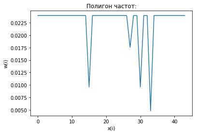

```python
plt.plot(values, rel_frequencies)
plt.title("Полигон частот:")
plt.xlabel("x(i)")
plt.ylabel("w(i)")
plt.show()
```

Следующим шагом посчитаем и построим функцию распределения и построим её график:

$$F(x) = P(X < x)$$

```python
cum_frequencies = [sum(rel_frequencies[0:index]) for index, value in enumerate(rel_frequencies)]
pd.DataFrame({"x":values, "w":rel_frequencies, "F(x)":cum_frequencies })
```

|  | F(x) | w | x |
| --- | --- | --- | --- |
| 0 | 0.000000 | 0.023962 | 0 |
| 1 | 0.023962 | 0.023962 | 1 |
| 2 | 0.047923 | 0.023962 | 2 |
| 3 | 0.071885 | 0.023962 | 3 |
| 4 | 0.095847 | 0.023962 | 4 |
| 5 | 0.119808 | 0.023962 | 5 |
| 6 | 0.143770 | 0.023962 | 6 |
| 7 | 0.167732 | 0.023962 | 7 |
| 8 | 0.191693 | 0.023962 | 8 |
| 9 | 0.215655 | 0.023962 | 9 |
| 10 | 0.239617 | 0.023962 | 10 |
| 11 | 0.263578 | 0.023962 | 11 |
| 12 | 0.287540 | 0.023962 | 12 |
| 13 | 0.311502 | 0.023962 | 13 |
| 14 | 0.335463 | 0.023962 | 14 |
| 15 | 0.359425 | 0.009585 | 15 |
| 16 | 0.369010 | 0.023962 | 16 |
| 17 | 0.392971 | 0.023962 | 17 |
| 18 | 0.416933 | 0.023962 | 18 |
| 19 | 0.440895 | 0.023962 | 19 |
| 20 | 0.464856 | 0.023962 | 20 |
| 21 | 0.488818 | 0.023962 | 21 |
| 22 | 0.512780 | 0.023962 | 22 |
| 23 | 0.536741 | 0.023962 | 23 |
| 24 | 0.560703 | 0.023962 | 24 |
| 25 | 0.584665 | 0.023962 | 25 |
| 26 | 0.608626 | 0.023962 | 26 |
| 27 | 0.632588 | 0.017572 | 27 |
| 28 | 0.650160 | 0.023962 | 28 |
| 29 | 0.674121 | 0.023962 | 29 |
| 30 | 0.698083 | 0.009585 | 30 |
| 31 | 0.707668 | 0.023962 | 31 |
| 32 | 0.731629 | 0.023962 | 32 |
| 33 | 0.755591 | 0.004792 | 33 |
| 34 | 0.760383 | 0.023962 | 34 |
| 35 | 0.784345 | 0.023962 | 35 |
| 36 | 0.808307 | 0.023962 | 36 |
| 37 | 0.832268 | 0.023962 | 37 |
| 38 | 0.856230 | 0.023962 | 38 |
| 39 | 0.880192 | 0.023962 | 39 |
| 40 | 0.904153 | 0.023962 | 40 |
| 41 | 0.928115 | 0.023962 | 41 |
| 42 | 0.952077 | 0.023962 | 42 |
| 43 | 0.976038 | 0.023962 | 43 |

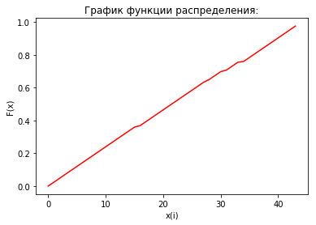

```python
plt.plot(values, cum_frequencies, color='red')
plt.title("График функции распределения:")
plt.xlabel("x(i)")
plt.ylabel("F(x)")
plt.show()
```

Посчитаем основные характеристики:

Математическое ожидание: $$M[X] = \frac{\sum_{i=1}^{n}x_i}{n}$$ или $$M[X] = \frac{\sum_{i=1}^{k}x_i^{'} n_i}{n}$$

```python
expectancy = sum(state) / n
print("Математическое ожидание = {}".format(expectancy))
```

```
Математическое ожидание = 21
```

Дисперсия: $$D[X] = \sigma^{2} = \frac{\sum_{i=1}^{n}(x_i - M[X])^{2}}{n}$$ или $$D[X] = \sigma^{2} = \frac{\sum_{i=1}^{k}(x_i^{'} - M[X])^{2}n_i}{n}$$

```python
variance = sum([(x - expectancy) ** 2 for x in state]) / n
print("Дисперсия = {}".format(variance))
```

```
Дисперсия = 165
```

Среднее квадратичное отклонение: $$\sigma = \sqrt{D[X]}$$

```python
standard_deviation = np.sqrt(variance)
print("Среднее квадратичное отклонение = {}".format(standard_deviation))
```

```
Среднее квадратичное отклонение = 12.8452325787
```

```python
median = np.median(state)
print("Медиана = {}".format(median))
```

```
Медиана = 21.0
```

Исходя из визуального представления функций распределения и частот выдвинем гипотезу, что данное распределение является равномерным.

Теоретические частоты:

$$m^{'} = \frac{1}{n}$$

где n - число уникальных вариант

```python
theor_frequencies = [1.0 / float(len(values)) for x in values]
pd.DataFrame({"m": rel_frequencies, "$m^{'}$": theor_frequencies})
```

|  | $m^{'}$ | m |
| --- | --- | --- |
| 0 | 0.022727 | 0.023962 |
| 1 | 0.022727 | 0.023962 |
| 2 | 0.022727 | 0.023962 |
| 3 | 0.022727 | 0.023962 |
| 4 | 0.022727 | 0.023962 |
| 5 | 0.022727 | 0.023962 |
| 6 | 0.022727 | 0.023962 |
| 7 | 0.022727 | 0.023962 |
| 8 | 0.022727 | 0.023962 |
| 9 | 0.022727 | 0.023962 |
| 10 | 0.022727 | 0.023962 |
| 11 | 0.022727 | 0.023962 |
| 12 | 0.022727 | 0.023962 |
| 13 | 0.022727 | 0.023962 |
| 14 | 0.022727 | 0.023962 |
| 15 | 0.022727 | 0.009585 |
| 16 | 0.022727 | 0.023962 |
| 17 | 0.022727 | 0.023962 |
| 18 | 0.022727 | 0.023962 |
| 19 | 0.022727 | 0.023962 |
| 20 | 0.022727 | 0.023962 |
| 21 | 0.022727 | 0.023962 |
| 22 | 0.022727 | 0.023962 |
| 23 | 0.022727 | 0.023962 |
| 24 | 0.022727 | 0.023962 |
| 25 | 0.022727 | 0.023962 |
| 26 | 0.022727 | 0.023962 |
| 27 | 0.022727 | 0.017572 |
| 28 | 0.022727 | 0.023962 |
| 29 | 0.022727 | 0.023962 |
| 30 | 0.022727 | 0.009585 |
| 31 | 0.022727 | 0.023962 |
| 32 | 0.022727 | 0.023962 |
| 33 | 0.022727 | 0.004792 |
| 34 | 0.022727 | 0.023962 |
| 35 | 0.022727 | 0.023962 |
| 36 | 0.022727 | 0.023962 |
| 37 | 0.022727 | 0.023962 |
| 38 | 0.022727 | 0.023962 |
| 39 | 0.022727 | 0.023962 |
| 40 | 0.022727 | 0.023962 |
| 41 | 0.022727 | 0.023962 |
| 42 | 0.022727 | 0.023962 |
| 43 | 0.022727 | 0.023962 |

Для проверки на равномерное распределение вычислим критерий Пирсона:

$$\chi^{2} = \sum\frac{(m_i - m_i^{'})^{2}}{m_i^{'}}$$

```python
xi_squared = sum([((rel_frequencies[i] - theor_frequencies[i]) ** 2)
                  / theor_frequencies[i] for i in range(len(rel_frequencies)) ])
print("Критерий Пирсона: {}".format(xi_squared))
```

```
Критерий Пирсона: 0.0332043809777
```

Число степеней свободы k = s - 3, где s - количество разных вариант.

```python
k = len(values) - 3
print("Число степеней свободы k: {}".format(k))
```

```
Число степеней свободы k: 41
```

Сравнив полученные результаты для $\chi^{2}$ с табличными, сделаем вывод, что полученное значение хи-квадрат значительно меньше табличных. Следовательно, нет основания отвергать гипотезу.

Далее проведём расчёты для общего веса произведённого мёда в фунтах:

```python
frequencies_dict = Counter(totalprod)
values = np.array(frequencies_dict.keys())
values.sort()
frequencies = np.array([frequencies_dict[key] for key in values])
rel_frequencies = np.divide(frequencies.astype(float), n)
vrange = np.ptp(values)
print("Размах (максимальное - минимальное значение): {}".format(vrange))
```

```
Размах (максимальное - минимальное значение): 46326000.0
```

Определим шаг по формуле Стерджесса $$h = \frac{x_{max} - x_{min}}{1 + 3,22\lg n}$$

```python
min_value = np.amin(totalprod)
max_value = np.amax(totalprod)
vrange = max_value - min_value
h = (max_value - min_value) / (1 + 3.22 * np.log10(n)) # шаг
k = int(np.floor((max_value - min_value) / h)) # количество интервалов
frequencies_dict = Counter(totalprod)
values = np.array(frequencies_dict.keys())
values.sort()
totalprod = np.array(totalprod)
print("Минимальное значение: {} Максимальное значение: {} Шаг: {} k: {}".format(min_value, max_value, h, k))
```

```
Минимальное значение: 84000.0 Максимальное значение: 46410000.0 Шаг: 4630299.04099 k: 10
```

Вычислим основные характеристики:

```python
expectancy = np.mean(totalprod)
variance = np.var(totalprod)
standard_deviation = np.std(totalprod)
median = np.median(totalprod)
print("Мат.ожидание: {}\nДисперсия: {}\nСтанд.отклонение: {}\nМедиана: {}\n"
      .format(expectancy, variance, standard_deviation, median))
```

```
Мат.ожидание: 4169086.26198
Дисперсия: 4.7311647459e+13
Станд.отклонение: 6878346.27356
Медиана: 1533000.0
```

Построим таблицу и график распределения:

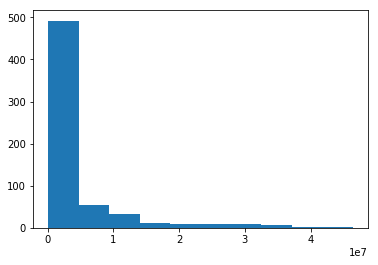

```python
ints, bins, patches = plt.hist(totalprod)
mids = [(bins[i] + bins[i + 1]) / 2 for i in range(k)]
rel_frequencies_group = np.divide(ints, n)
plt.show()
```

```python
pd.DataFrame({"n":ints, "$x_a, x_b$":["[ {} ; {} ]"
                                   .format(bins[i], bins[i + 1]) for i in range(k)],
              "$w_i$":rel_frequencies_group, "$x_i$":mids})
```

|  | $w_i$ | $x_a, x_b$ | $x_i$ | n |
| --- | --- | --- | --- | --- |
| 0 | 0.785942 | [ 84000.0 ; 4716600.0 ] | 2400300.0 | 492.0 |
| 1 | 0.087859 | [ 4716600.0 ; 9349200.0 ] | 7032900.0 | 55.0 |
| 2 | 0.051118 | [ 9349200.0 ; 13981800.0 ] | 11665500.0 | 32.0 |
| 3 | 0.019169 | [ 13981800.0 ; 18614400.0 ] | 16298100.0 | 12.0 |
| 4 | 0.012780 | [ 18614400.0 ; 23247000.0 ] | 20930700.0 | 8.0 |
| 5 | 0.014377 | [ 23247000.0 ; 27879600.0 ] | 25563300.0 | 9.0 |
| 6 | 0.015974 | [ 27879600.0 ; 32512200.0 ] | 30195900.0 | 10.0 |
| 7 | 0.009585 | [ 32512200.0 ; 37144800.0 ] | 34828500.0 | 6.0 |
| 8 | 0.001597 | [ 37144800.0 ; 41777400.0 ] | 39461100.0 | 1.0 |
| 9 | 0.001597 | [ 41777400.0 ; 46410000.0 ] | 44093700.0 | 1.0 |

Проведём анализ разбиения на группы, для чего вычислим:

Межгрупповую дисперсию:

$$\sigma_{мг}^{2} = \frac{\sum_{i=1}^{k} (\tilde{x_i} - \tilde{x_{общ}})^{2} * f_i}{\sum_{i=1}^{k}f_i}$$

```python
mean = np.mean(totalprod)
#межгрупповая дисперсия
intergroup_var = sum([((np.mean(totalprod[np.where((totalprod > bins[i]) & (totalprod <= bins[i + 1]))])
                    - mean) ** 2) * rel_frequencies_group[i] for i in range(k)]) / sum(rel_frequencies_group)
print("Межгрупповая дисперсия: {}".format(intergroup_var))
```

```
Межгрупповая дисперсия: 4.56717918411e+13
```

Внутригрупповые дисперсии:

$$\sigma_{j}^{2} = \frac{\sum_{i=1}^{n}(x_i - \tilde{x_j})^{2}}{n}$$

```python
#средняя из внутригрупповых дисперсий
ingroup_var = np.mean([np.var(totalprod[np.where((totalprod > bins[i]) & (totalprod <= bins[i + 1]))])
                       for i in range(k)])
print("Средняя из внутригрупповых дисперсий: {}".format(ingroup_var))
```

```
Средняя из внутригрупповых дисперсий: 1.40778336859e+12
```

По правилу сложения дисперсий, дисперсия равна сумме средней из внутригрупповых дисперсий и межгрупповой дисперсии: $$\sigma^{2} = \sigma_{мг}^{2} + \tilde{\sigma^{2}}$$

```python
print("Дисперсия: {}\nСумма: {}".format(variance, ingroup_var + intergroup_var))
print("Различие: {} %".format(np.abs(variance - (ingroup_var + intergroup_var)) / variance * 100))
```

```
Дисперсия: 4.7311647459e+13
Сумма: 4.70795752097e+13
Различие: 0.49051821647 %
```

Построим функцию распределения для $x_i$:

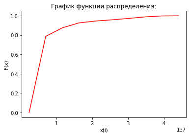

```python
cum_frequencies = [sum(rel_frequencies_group[0:index]) for index, value in enumerate(rel_frequencies_group)]
plt.plot(mids, cum_frequencies, color='red')
plt.title("График функции распределения:")
plt.xlabel("x(i)")
plt.ylabel("F(x)")
plt.show()
```

Проанализировав графики, выдвинем гипотезу, что данное распределение является экспоненциальным (показательным). Для проверки гипотезы используем критерий согласия Пирсона.

Вычислим теоретические частоты по формуле для экспоненциального распределения при x > 0:

$$f(x) = \lambda e^{-\lambda x}$$

где $$\lambda = \frac{1}{\tilde{x}}$$

```python
lmbd = 1.0 / expectancy
theor_frequencies = [lmbd * np.exp(-1 * lmbd * x) for x in mids]
```

$$\chi^{2} = \sum\frac{(m_i - m_i^{'})^{2}}{m_i^{'}}$$

```python
xi_squared = sum([((rel_frequencies_group[i] - theor_frequencies[i]) ** 2)
                  / theor_frequencies[i] for i in range(len(rel_frequencies_group)) ])
print("Критерий Пирсона: {}".format(xi_squared))
```

```
Критерий Пирсона: 9176947.75294
```

Полученное значение гораздо больше табличного, значит, гипотеза опровергается.

Далее проведём анализ цены за фунт (непрерывной величины):

```python
frequencies_dict = Counter(priceperlb)
values = np.array(frequencies_dict.keys())
values.sort()
frequencies = np.array([frequencies_dict[key] for key in values])
rel_frequencies = np.divide(frequencies.astype(float), n)
vrange = np.ptp(values)
print("Размах (максимальное - минимальное значение): {}".format(vrange))
```

```
Размах (максимальное - минимальное значение): 3.66
```

Определим шаг по формуле Стерджесса $$h = \frac{x_{max} - x_{min}}{1 + 3,22\lg n}$$

```python
min_value = np.amin(priceperlb)
max_value = np.amax(priceperlb)
vrange = max_value - min_value
h = (max_value - min_value) / (1 + 3.22 * np.log10(n)) # шаг
k = int(np.floor((max_value - min_value) / h)) # количество интервалов
frequencies_dict = Counter(priceperlb)
values = np.array(frequencies_dict.keys())
values.sort()
priceperlb = np.array(priceperlb)
print("Минимальное значение: {} Максимальное значение: {} Шаг: {}".format(min_value, max_value, h))
```

```
Минимальное значение: 0.49 Максимальное значение: 4.15 Шаг: 0.365818212019
```

Построим таблицу и график распределения:

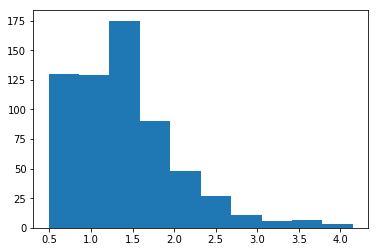

```python
ints, bins, patches = plt.hist(priceperlb)
mids = [(bins[i] + bins[i + 1]) / 2 for i in range(k)]
rel_frequencies_group = np.divide(ints, n)
plt.show()
```

```python
pd.DataFrame({"n":ints, "$x_a, x_b$":["[ {} ; {} ]"
                                   .format(bins[i], bins[i + 1]) for i in range(k)],
              "$w_i$":rel_frequencies_group, "$x_i$":mids})
```

|  | $w_i$ | $x_a, x_b$ | $x_i$ | n |
| --- | --- | --- | --- | --- |
| 0 | 0.207668 | [ 0.49 ; 0.856 ] | 0.673 | 130.0 |
| 1 | 0.206070 | [ 0.856 ; 1.222 ] | 1.039 | 129.0 |
| 2 | 0.279553 | [ 1.222 ; 1.588 ] | 1.405 | 175.0 |
| 3 | 0.143770 | [ 1.588 ; 1.954 ] | 1.771 | 90.0 |
| 4 | 0.076677 | [ 1.954 ; 2.32 ] | 2.137 | 48.0 |
| 5 | 0.043131 | [ 2.32 ; 2.686 ] | 2.503 | 27.0 |
| 6 | 0.017572 | [ 2.686 ; 3.052 ] | 2.869 | 11.0 |
| 7 | 0.009585 | [ 3.052 ; 3.418 ] | 3.235 | 6.0 |
| 8 | 0.011182 | [ 3.418 ; 3.784 ] | 3.601 | 7.0 |
| 9 | 0.004792 | [ 3.784 ; 4.15 ] | 3.967 | 3.0 |

Вычислим основные характеристики:

```python
expectancy = np.mean(priceperlb)
variance = np.var(priceperlb)
standard_deviation = np.std(priceperlb)
median = np.median(priceperlb)
print("Мат.ожидание: {}\nДисперсия: {}\nСтанд.отклонение: {}\nМедиана: {}\n"
      .format(expectancy, variance, standard_deviation, median))
```

```
Мат.ожидание: 1.4095686901
Дисперсия: 0.407157162215
Станд.отклонение: 0.638088678958
Медиана: 1.36
```

Проведём анализ разбиения на группы, для чего вычислим:

Межгрупповую дисперсию:

$$\sigma_{мг}^{2} = \frac{\sum_{i=1}^{k} (\tilde{x_i} - \tilde{x_{общ}})^{2} * f_i}{\sum_{i=1}^{k}f_i}$$

```python
mean = np.mean(priceperlb)
#межгрупповая дисперсия
intergroup_var = sum([((np.mean(priceperlb[np.where((priceperlb > bins[i]) & (priceperlb <= bins[i + 1]))])
                    - mean) ** 2) * rel_frequencies_group[i] for i in range(k)]) / sum(rel_frequencies_group)
print("Межгрупповая дисперсия: {}".format(intergroup_var))
```

```
Межгрупповая дисперсия: 0.39672335809
```

Внутригрупповые дисперсии:

$$\sigma_{j}^{2} = \frac{\sum_{i=1}^{n}(x_i - \tilde{x_j})^{2}}{n}$$

```python
#средняя из внутригрупповых дисперсий
ingroup_var = np.mean([np.var(priceperlb[np.where((priceperlb > bins[i]) & (priceperlb <= bins[i + 1]))])
                       for i in range(k)])
print("Средняя из внутригрупповых дисперсий: {}".format(ingroup_var))
```

```
Средняя из внутригрупповых дисперсий: 0.0102410605487
```

По правилу сложения дисперсий, дисперсия равна сумме средней из внутригрупповых дисперсий и межгрупповой дисперсии: $$\sigma^{2} = \sigma_{мг}^{2} + \tilde{\sigma^{2}}$$

```python
print("Дисперсия: {}\nСумма: {}".format(variance, ingroup_var + intergroup_var))
print("Различие: {} %".format(np.abs(variance - (ingroup_var + intergroup_var)) / variance * 100))
```

```
Дисперсия: 0.407157162215
Сумма: 0.406964418639
Различие: 0.0473388641772 %
```

А также функцию распределения для $x_i$:

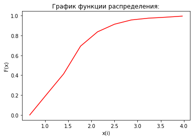

```python
cum_frequencies = [sum(rel_frequencies_group[0:index]) for index, value in enumerate(rel_frequencies_group)]
plt.plot(mids, cum_frequencies, color='red')
plt.title("График функции распределения:")
plt.xlabel("x(i)")
plt.ylabel("F(x)")
plt.show()
```

Исходя из визуального представления функций распределения и частот выдвинем гипотезу, что данное распределение является нормальным.

Теоретические частоты:

$$m' = \frac{1}{\sigma\sqrt{2\pi}}e^{-\frac{(x - \mu)^{2}}{2\sigma^{2}}}$$

```python
theor_frequencies = [(1.0 / (standard_deviation * np.sqrt(2*np.pi)) *
                     np.exp(-1 * ((x - mean) ** 2) / (2 * variance))) for x in mids]
```

Для проверки вычислим критерий Пирсона:

$$\chi^{2} = \sum\frac{(m_i - m_i^{'})^{2}}{m_i^{'}}$$

```python
xi_squared = sum([((rel_frequencies_group[i] - theor_frequencies[i]) ** 2)
                  / theor_frequencies[i] for i in range(len(rel_frequencies_group)) ])
print("Критерий Пирсона: {}".format(xi_squared))
```

```
Критерий Пирсона: 1.14645719373
```

Полученное значение меньше табличного, значит, гипотеза не опровергается.

Критерий Романовского находим по формуле:

$$R = \frac{|\chi^{2} - k|}{\sqrt{2k}}$$

```python
R = np.abs(xi_squared - k) / np.sqrt(2 * k)
print("Критерий Романовского: {}".format(R))
```

```
Критерий Романовского: 1.97971235565
```

Полученное значение меньше 3, значит, гипотеза не опровергается.

Вычислим значение критерия Ястремского:

$$J = \frac{|\chi^{2} - k|}{\sqrt{2k + 2,4}}$$

```python
J = np.abs(xi_squared - k) / np.sqrt(2 * k + 2.4)
print("Критерий Ястремского: {}".format(J))
```

```
Критерий Ястремского: 1.87065234303
```

Полученный результат меньше 3, значит, гипотеза не опровергается.

Таким образом, на основании критериев Пирсона, Романовского и Ястремского можно сделать вывод, что гипотеза подтверждается и данное распределение является нормальным.

## Шаг 3. Вывод

В данной расчетной работе были проанализированы три набора статистических данных (один дискретный и два непрерывных). Значения были очищены и отсортированы. Для непрерывных величин значения были разбиты на интервалы и проведен анализ качества разбиения на группы. Для каждого вариационного ряда были построены таблицы распределения, гистограммы/полигон частот, вычислены основные числовые характеристики.

На основании гистограммы/полигона частот были выдвинуты гипотезы о виде распределения величин. Для подтверждения гипотез использовались критерии согласия Пирсона, Романовского и Ястремского. При этом были приняты две из трёх гипотез для наборов данных. Первый набор данных является равномерным распределением, для второго по критерию Пирсона была опровергнута гипотеза об экспоненциальном (показательном) распределении, а третий набор является нормальным распределением.